# PANORAMIC tutorial

# Introduction

Spatial transcriptomics experiments increasingly profile multiple samples across conditions, yet most statistical methods still perform colocalization analysis sample by sample, or rely on ad hoc aggregation of summary measures. The panoramic package (Pooled ANalysis Of vaRiance-aware Modeling and Inference of Colocalization) provides a principled meta-analytic framework for pooling spatial colocalization statistics across many samples while accounting for within-sample uncertainty and between-sample heterogeneity.

PANORAMIC takes as input a collection of spatial omics samples, represented as SpatialExperiment objects, and computes spatial summary statistics (such as L-functions) for all pairs of cell types at user-specified radii. These summaries are then modeled using random-effects meta-analysis, enabling robust estimation of group-level spatial associations and formal testing of differences between biological conditions.

Compared to existing tools that focus on single-sample spatial statistics or descriptive visualizations, PANORAMIC emphasizes pooled inference across experiments, explicit modeling of variance, and reproducible meta-analytic summaries of spatial colocalization. This makes it particularly well suited for multi-sample, multi-cohort spatial studies where rigorous cross-sample inference is required.

```r
# Installation
# devtools::install_github("plevritis-lab/panoramic")
```

```r
library(panoramic)
library(SpatialExperiment)
library(dplyr)
```

```r
library(SpatialExperiment)
library(S4Vectors)
library(BiocParallel)
library(ggplot2)

set.seed(123)
```

First, we will simulate some spatial data with three cell types: (A), (B), and (C). The first group of samples will be randomly dispersed in the tissue area, while the second group of samples with exhibit more clustering of cell types. We will also create a design matrix to keep track of which samples belong to each group.

```r
# Helper: turn a data.frame into a SpatialExperiment -----------------------
df_to_spe <- function(df) {
  stopifnot(all(c("sample", "x", "y", "cell_type") %in% colnames(df)))

  coords <- as.matrix(df[, c("x", "y")])
  rownames(coords) <- paste0(df$sample, "_cell", seq_len(nrow(df)))

  # dummy counts (not used by PANORAMIC)
  expr <- matrix(
    rpois(10 * nrow(df), lambda = 5),
    nrow = 10,
    dimnames = list(paste0("gene", seq_len(10)), rownames(coords))
  )

  SpatialExperiment::SpatialExperiment(
    assays = list(counts = expr),
    colData = S4Vectors::DataFrame(
      cell_type = df$cell_type,
      sample_id = df$sample
    ),
    spatialCoords = coords
  )
}

# Simulate group 1 ---------------------------------------------------------
group1_spe_list <- list()

for (i in 1:3) {
  n <- round(rnorm(n = 1, mean = 200, sd = 100))
  n <- max(n, 50)  # ensure positive / nontrivial

  x <- runif(n = n, min = 0, max = 100)
  y <- runif(n = n, min = 0, max = 100)
  cell_type <- sample(
    x = c("(A)", "(B)", "(C)"),
    size = n,
    replace = TRUE
  )

  df <- data.frame(
    sample    = paste0("sample_", i),
    x         = x,
    y         = y,
    cell_type = cell_type,
    stringsAsFactors = FALSE
  )

  group1_spe_list[[i]] <- df_to_spe(df)
}

names(group1_spe_list) <- paste0("sample_", 1:3)

# Simulate group 2 ---------------------------------------------------------
group2_spe_list <- list()

for (j in 1:3) {
  n <- round(rnorm(n = 1, mean = 400, sd = 100))
  n <- max(n, 50)

  x <- rnorm(n = n, mean = 50, sd = 20)
  y <- rnorm(n = n, mean = 50, sd = 20)
  cell_type <- sample(
    x = c("(A)", "(B)", "(C)"),
    size = n,
    replace = TRUE
  )

  df <- data.frame(
    sample    = paste0("sample_", j + 3),
    x         = x,
    y         = y,
    cell_type = cell_type,
    stringsAsFactors = FALSE
  ) |>
    dplyr::filter(dplyr::between(x, 0, 100) & dplyr::between(y, 0, 100))

  group2_spe_list[[j]] <- df_to_spe(df)
}

names(group2_spe_list) <- paste0("sample_", 4:6)

# Combine into one list for PANORAMIC -------------------------------------
spe_list <- c(group1_spe_list, group2_spe_list)

# Design data.frame mapping samples to groups ------------------------------
design <- data.frame(
  sample = paste0("sample_", 1:6),
  group  = c(rep("group1", 3), rep("group2", 3)),
  stringsAsFactors = FALSE
)
```

Visualize the samples.

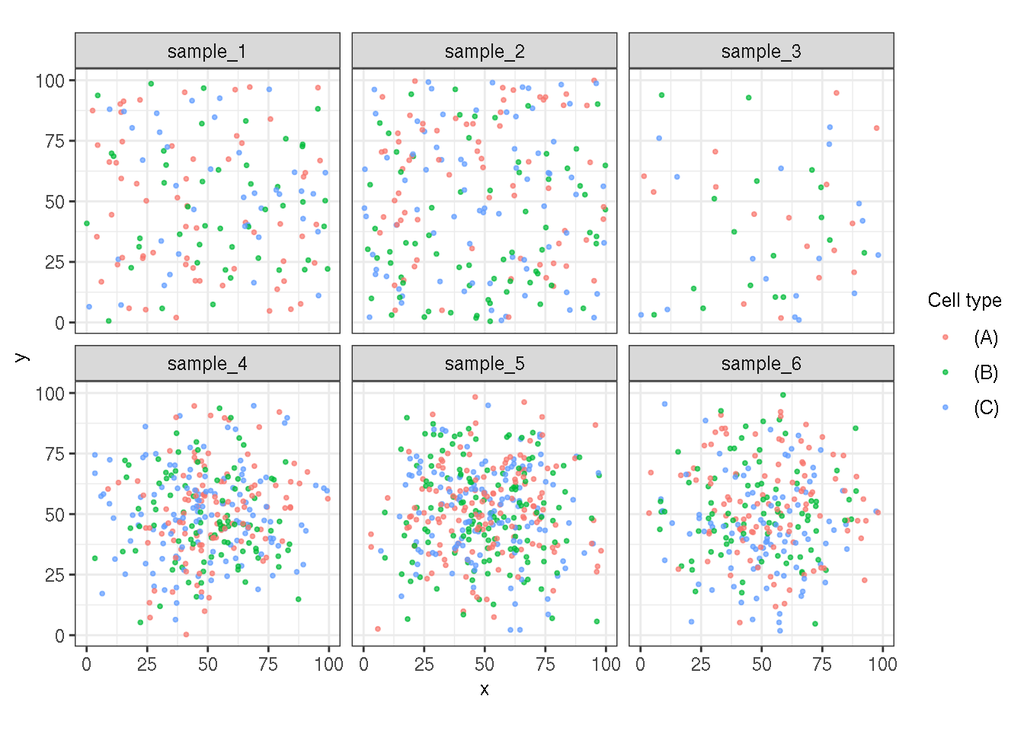

```r
plot_df <- do.call(rbind, lapply(spe_list, function(spe) {
  coords <- SpatialExperiment::spatialCoords(spe)
  df <- as.data.frame(coords)
  df$cell_type <- colData(spe)$cell_type
  df$sample_id <- colData(spe)$sample_id
  df
}))

ggplot(plot_df, aes(x = x, y = y, color = cell_type)) +
  geom_point(size = 0.7, alpha = 0.7) +
  facet_wrap(~ sample_id, nrow = 2) +
  coord_equal() +
  theme_bw() +
  labs(x = "x", y = "y", color = "Cell type")
```

Next, we will run the PANORAMIC workflow. We will specify the spatial distance of colocalization a 10 micron, and we will use the Ripley’s cross-L function as our spatial statistic. For now, we will use 50 simulations for our spatial bootstrapping, but when running this on real data, we recommend running nim >= 100.

```r
# Preparation step and calculation of spatial statistics + bootstrapping.
se <- panoramic(
  spe_list,
  design      = design,
  cell_type   = "cell_type",
  radii_um    = c(10),
  stat        = "Lcross",
  nsim        = 50,
  BPPARAM     = BiocParallel::SerialParam()
)
# Meta-analysis step to pool estimates robustly across multiple spatial samples.
se_meta <- panoramic_meta(se, tau2 = "SJ", group_col = "group")

# Differential testing step to compare colocalization estimates between groups.
se_diff <- panoramic_compare_groups(se_meta, group1 = "group1", group2 = "group2")
```

```
## Using radius: 10 um
```

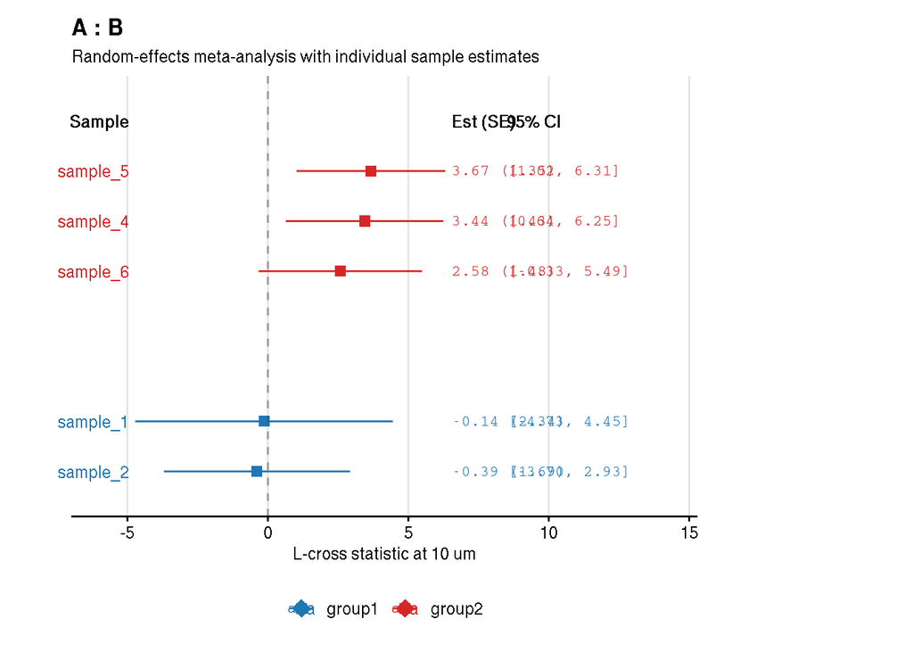

```r
# Inspect the meta-analysis outputs for a pair of cell-types
plot_forest(se_meta,
            ct1 = "(A)",
            ct2 = "(B)",
            show_heterogeneity = TRUE)
```

```r
# Inspect the significant results after FDR correction
res <- as.data.frame(rowData(se_diff))
res |> filter(fdr_diff < 0.05)
```

```
##            ct1 ct2 radius_um   stat group1_mu_hat group1_se_mu  group1_tau2
## (A)|(A)|10 (A) (A)        10 Lcross    0.43219728    1.0775281 0.0231845410
## (B)|(A)|10 (B) (A)        10 Lcross   -0.27406148    1.2025255 0.0001655401
## (A)|(B)|10 (A) (B)        10 Lcross   -0.30125175    1.3712137 0.0001160267
## (A)|(C)|10 (A) (C)        10 Lcross    0.09953229    0.9969335 0.0095005703
## (B)|(C)|10 (B) (C)        10 Lcross   -0.07551934    1.0401887 0.0013593665
##               group1_Q   group1_I2 group1_k group1_p_mu group2_mu_hat
## (A)|(A)|10 0.147067653 0.997322311        2   0.6883460      3.527222
## (B)|(A)|10 0.010678608 0.005671031        2   0.8197202      3.313463
## (A)|(B)|10 0.007472677 0.002781575        2   0.8261070      3.261210
## (A)|(C)|10 0.080041250 0.307057838        2   0.9204726      3.318056
## (B)|(C)|10 0.027991643 0.038620943        2   0.9421232      2.995228
##            group2_se_mu group2_tau2  group2_Q group2_I2 group2_k  group2_p_mu
## (A)|(A)|10    0.8238526  0.13902562 0.7256950 6.8035669        3 1.857419e-05
## (B)|(A)|10    1.0048619  0.02083509 0.2020878 0.6694002        3 9.757354e-04
## (A)|(B)|10    0.8254915  0.03169329 0.3182367 1.5458055        3 7.794619e-05
## (A)|(C)|10    0.8595028  0.04561062 0.3719383 2.0119412        3 1.131849e-04
## (B)|(C)|10    0.7930619  0.04562650 0.4314746 2.1790670        3 1.588630e-04
##            beta_diff  se_diff   z_diff     p_diff   fdr_diff  mu_control
## (A)|(A)|10  3.095025 1.356392 2.281807 0.02250076 0.04164244  0.43219728
## (B)|(A)|10  3.587524 1.567104 2.289270 0.02206366 0.04164244 -0.27406148
## (A)|(B)|10  3.562462 1.600520 2.225816 0.02602652 0.04164244 -0.30125175
## (A)|(C)|10  3.218523 1.316291 2.445146 0.01447935 0.04164244  0.09953229
## (B)|(C)|10  3.070747 1.308029 2.347614 0.01889409 0.04164244 -0.07551934
##            se_control tau2_control  mu_case   se_case  tau2_case
## (A)|(A)|10  1.0775281 0.0231845410 3.527222 0.8238526 0.13902562
## (B)|(A)|10  1.2025255 0.0001655401 3.313463 1.0048619 0.02083509
## (A)|(B)|10  1.3712137 0.0001160267 3.261210 0.8254915 0.03169329
## (A)|(C)|10  0.9969335 0.0095005703 3.318056 0.8595028 0.04561062
## (B)|(C)|10  1.0401887 0.0013593665 2.995228 0.7930619 0.04562650
```

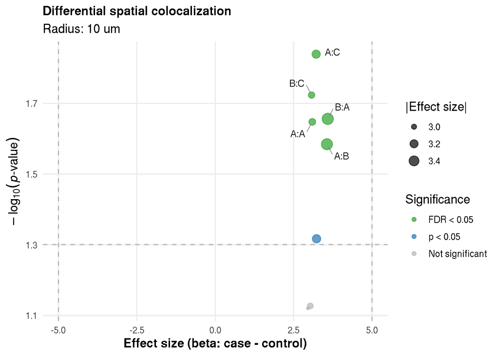

```r
# Visualize the results as a volcano-plot
# NOTE: this volcano plot is strange looking because only group2 displayed higher
# colocalization betweeen various pairs of cell types.
plot_volcano(se_diff)
```

We can also visualize our differential testing results as a network and perform clustering to discover subnetworks of colocalization across mutliple cell types. In this toy example we only have three cell types, but in larger settings, you can see colocalization subnetworks of 2+ cell types.

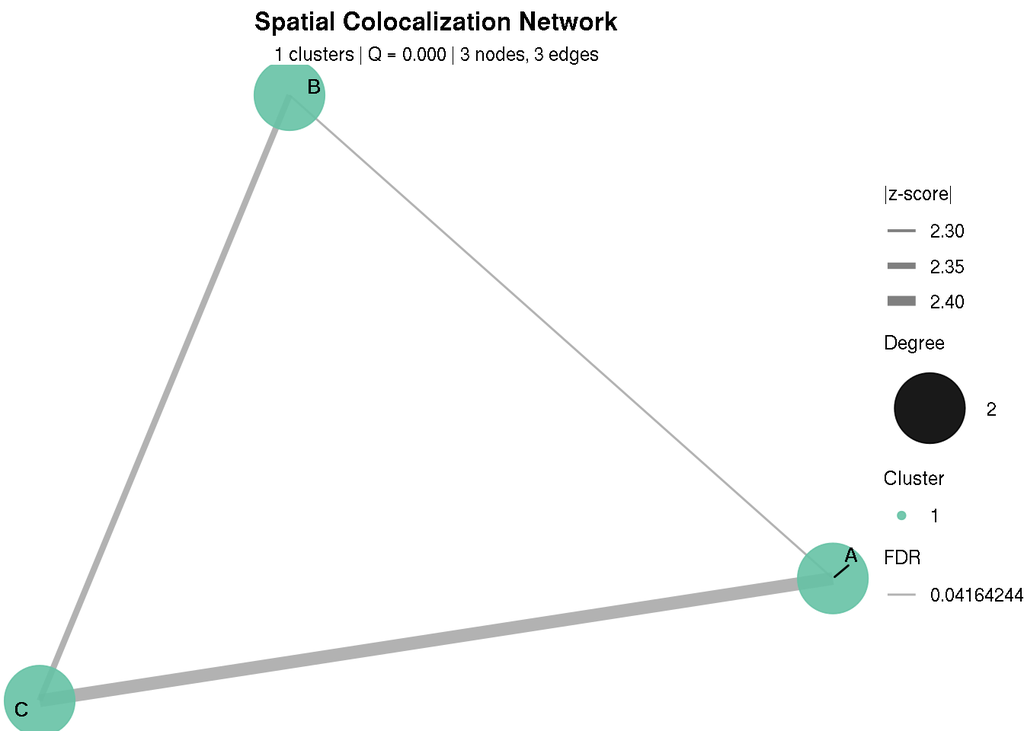

```r
net <- create_spatial_network(se_diff,
                              fdr_threshold = 0.9,
                              directed = FALSE,
                              leiden_resolution = 1.0)
plot_spatial_network(net,
                     layout = "fr",
                     node_size_by = "degree")
```